# MTH6139 Time Series

Coursework 1

Brody Willis

Spring term 2025

# Overview:

> 🏎️ **What is the data about?**

> The data I have chosen to use is the fastest Formula 1 (F1) lap time recorded every year in the monaco grand prix. The name of the track is Monte-Carlo which is used for some variable names.

> Every fastest lap time was taken from the fastest lap within the grand prix race held that year (not from any practice or qualifying sessions) meaning they are all held under more or less the same conditions. Historical lap time data was taken from GP Racing Stats (2026) and is recorded in seconds - see reference section.

> 📈️ **What is the aim of this project?**

> The purpose of this project is to utilise Meta’s Prophet forecasting system on the lap time data to create a forecast and to try and predict how fast the lap times will be in the future, focusing on details like overall trends and variability of the time series and comment on potential reasons or causes of this.

# Shaping the Data:

In this section I will show the steps I took to import the data into R, clean it of unnecessary data and making it ready for the meta prophet forecasting system.

I had to do some research as to how to import this data from the URL listed above as it is not the same as the usual method of using csv files or data frames already built into R. Here are the libraries I required for the steps below:

```r
library(rvest)
library(dplyr)
library(tidyr)
library(zoo)
library(prophet)
library(ggplot2)
```

## Importing and tidying:

1. First I imported the data in the table from the URL.

```r
url= "https://gpracingstats.com/circuits/monte-carlo/fastest-laps/"
tables= url %>%
    read_html() %>%
    html_table(fill=TRUE) #read the html and the table within it
montecarlo_dataframe= tables[[1]] #create a dataframe equal to the table we desire
head(montecarlo_dataframe)
```

```
## # A tibble: 6 × 5
##    Year `Grand Prix` Driver                   Constructor   `Lap time`
##   <int> <chr>        <chr>                    <chr>         <chr>
## 1  1950 Monaco       (ARG) Juan Manuel Fangio Alfa Romeo    1:51.000
## 2  1955 Monaco       (ARG) Juan Manuel Fangio Mercedes      1:42.400
## 3  1956 Monaco       (ARG) Juan Manuel Fangio Ferrari       1:44.400
## 4  1957 Monaco       (ARG) Juan Manuel Fangio Maserati      1:45.600
## 5  1958 Monaco       (GBR) Mike Hawthorn      Ferrari       1:40.600
## 6  1959 Monaco       (AUS) Jack Brabham       Cooper-Climax 1:40.400
```

As you can see from the output, the table of data is saved in the variable ‘montecarlo_dataframe’. This data frame consists of 5 columns.

2. The next step is to remove all columns which are unnecessary information. We are only interested in the fastest lap times every year as a time series, so remove all other columns. (Also tidy the name of the lap time column to a single word).

```r
montecarlo_dataframe$`Grand Prix`=NULL
montecarlo_dataframe$Driver=NULL
montecarlo_dataframe$Constructor=NULL
colnames(montecarlo_dataframe)[2]="Laptime"
head(montecarlo_dataframe)
```

```
## # A tibble: 6 × 2
##    Year Laptime
##   <int> <chr>
## 1  1950 1:51.000
## 2  1955 1:42.400
## 3  1956 1:44.400
## 4  1957 1:45.600
## 5  1958 1:40.600
## 6  1959 1:40.400
```

3. Next we want the lap times to be measured in seconds only rather than minutes and seconds, simply so that it is easier at a glance to compare data points.

```r
montecarlo_dataframe=montecarlo_dataframe %>%
    mutate(
        minutes=as.numeric(sub(":.*","",Laptime)),
        seconds=as.numeric(sub(".*:","",Laptime)),
        lap_seconds=seconds + (60*minutes)
    )
#Now remove the temporary columns created in order to get the lap times in seconds
montecarlo_dataframe$Laptime=NULL
montecarlo_dataframe$minutes=NULL
montecarlo_dataframe$seconds=NULL
head(montecarlo_dataframe)
```

```
## # A tibble: 6 × 2
##    Year lap_seconds
##   <int>       <dbl>
## 1  1950        111
## 2  1955        102.
## 3  1956        104.
## 4  1957        106.
## 5  1958        101.
## 6  1959        100.
```

   We must fill those 5 gaps in the data where there are no lap times with N/A and then we can create a time series out of this:

```r
montecarlo_dataframe=montecarlo_dataframe %>%
    select(Year,lap_seconds) %>%
    complete(Year=1950:2025)
head(montecarlo_dataframe)
```

```
## # A tibble: 6 × 2
##    Year lap_seconds
##   <int>       <dbl>
## 1  1950        111
## 2  1951         NA
## 3  1952         NA
## 4  1953         NA
## 5  1954         NA
## 6  1955        102.
```

```r
tail(montecarlo_dataframe)
```

```
## # A tibble: 6 × 2
##    Year lap_seconds
##   <int>       <dbl>
## 1  2020        NA
## 2  2021        72.9
## 3  2022        74.7
## 4  2023        75.6
## 5  2024        74.2
## 6  2025        73.2
```

```r
montecarlo_time_series=ts(montecarlo_dataframe$lap_seconds,
                  start=montecarlo_dataframe$Year[1],
                  frequency=1)
```

## Meta Prophet’s Requirements:

In order to use the prophet forecasting system there are a few tweaks we must make to our data frame first.

1. The data frame must have the time column titled ‘ds’ and the data column titled ‘y’.
2. The time column must contain a vector of date objects (not just integers representing the year). This is done as follows:

```r
colnames(montecarlo_dataframe)=c('ds','y')
montecarlo_dataframe$ds=yearmon(montecarlo_dataframe$ds)
head(montecarlo_dataframe)
```

```
## # A tibble: 6 × 2
##   ds            y
##   <yearmon> <dbl>
## 1 Jan 1950   111
## 2 Jan 1951    NA
## 3 Jan 1952    NA
## 4 Jan 1953    NA
## 5 Jan 1954    NA
## 6 Jan 1955   102.
```

The data frame is now completely ready to start using the prophet forecasting.

# Analysis of the Time Series:

In this section I will discuss some of the things the time series shows along with some charts and some explanations.

> ❗️ **Remark**

> One important thing to note when analysing this data is that it has no seasonality. This is due to the data points being collected annually (once per year) since the Monaco Grand Prix is only held at most once per year.

## Trend:

In order to see the trend of the data we must plot the time series along with its linear regression line.

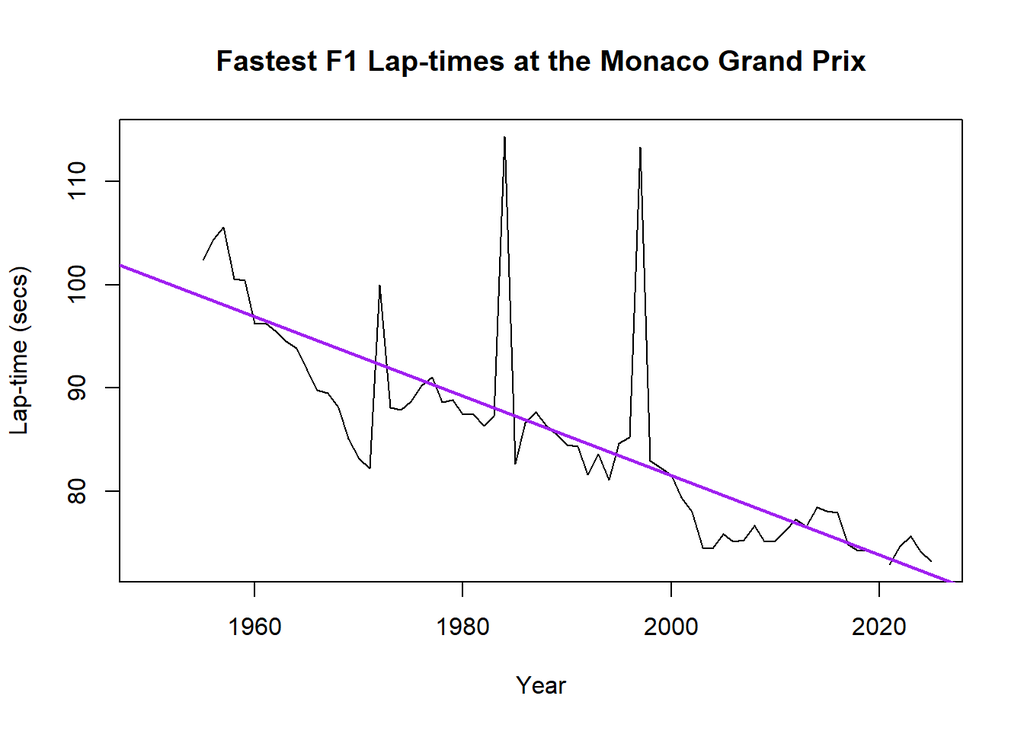

```r
lap_time_linear_model=lm(montecarlo_time_series~time(montecarlo_time_series))
plot(montecarlo_time_series,
     main='Fastest F1 Lap-times at the Monaco Grand Prix',
     ylab='Lap-time (secs)', xlab='Year')
abline(lap_time_linear_model,col='purple',lwd=2)
```

```r
coef(lap_time_linear_model)[2] #shows slope of the regression line
```

```
## time(montecarlo_time_series)
##                    -0.384581
```

*The graph above shows the lap times from the time series in black and the linear regression line of the data in purple.*

The time series clearly shows that there is a downward trend in the lap times over time and this is confirmed by the regression line. Furthermore, the slope of the line is estimated to be -0.3846. This means that the lap times decrease by approximately 0.38 seconds every year. However, we can see that the times do not decrease every year and there are even certain points where the times seem to spike. We will discuss these points and possible explanations a little later.

> **Moving Average**

> The intepretations above can also be validated by looking at a filtered version of the time series, namely using a 5 year moving average.

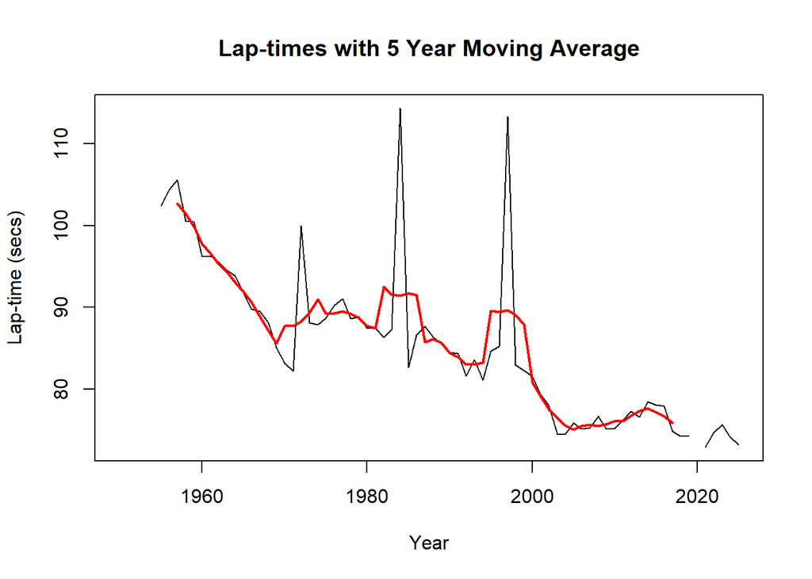

> ```r
> average_weights=c(1/5,1/5,1/5,1/5,1/5)
> moving_average=stats::filter(montecarlo_time_series,average_weights)
> plot(montecarlo_time_series,
>      main='Lap-times with 5 Year Moving Average',
>      ylab='Lap-time (secs)',xlab='Year')
> lines(moving_average,col='red',lwd=2)
> ```

> *In this graph the unfiltered time series is once again shown in black and the filtered time series is shown in red.*

> As you can see from the graph, the data earlier years in 1956 to 1971 almost follow a perfectly straight decreasing line whereas from 2003 to 2018 the data seems to plateau, barely fluctuating at all. This confirms what was mentioned above that the lap times were more succeptible to change during the earlier years compared to the later years where it appears to have hit a limit.

## Variability:

In order to see the variability of the data we can calculate and plot the difference in lap times between consecutive years:

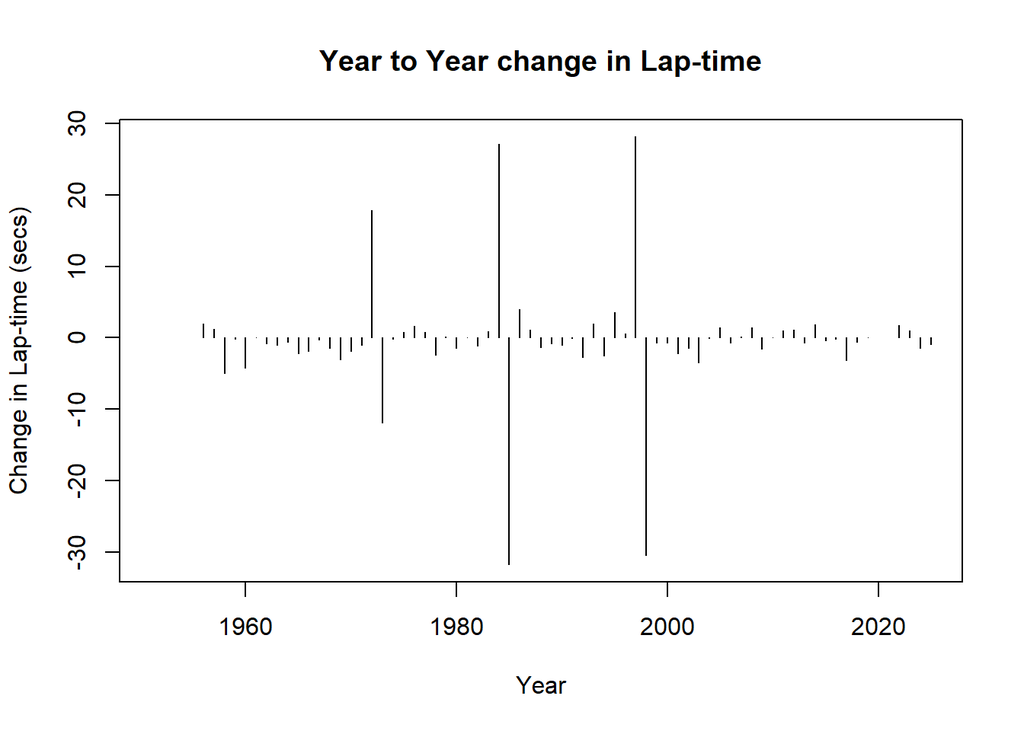

```r
delta=diff(montecarlo_time_series)
plot(time(montecarlo_time_series)[-1],delta,type='h',
     main='Year to Year change in Lap-time',
     ylab='Change in Lap-time (secs)',xlab='Year')
```

*This graph shows the year to year changes in lap time in seconds so that any lines that go downwards (below 0) represents when the lap times are faster than the year before it and vice versa.*

From the diagram we can see that the middle years of our data set (around 1973 to 2000) there is a similar number of negative and positive values (12 negative and 11 positive). This suggests that there was a lot of variability in lap time during this period as it is near impossible to predict whether a lap time would increase or decrease in the following year. This might be due to the many comprehensive regulation changes being made to the sport around this time and especially in the 1980s, where formula 1 said goodbye to the likes of manual transmission, chassis side-skirts and extreme under-body suction and even welcomed a complete change of engine, losing turbochargers and gaining 3.5 Litre naturally aspirated engines. Overall there were many more rules changes in this pivotal era which could potentially explain such unstable automotive progression.

## Points of Interest:

I mentioned earlier a few data points that seemed to spike in lap time much further than any others. Let’s take another look at the time series plot.

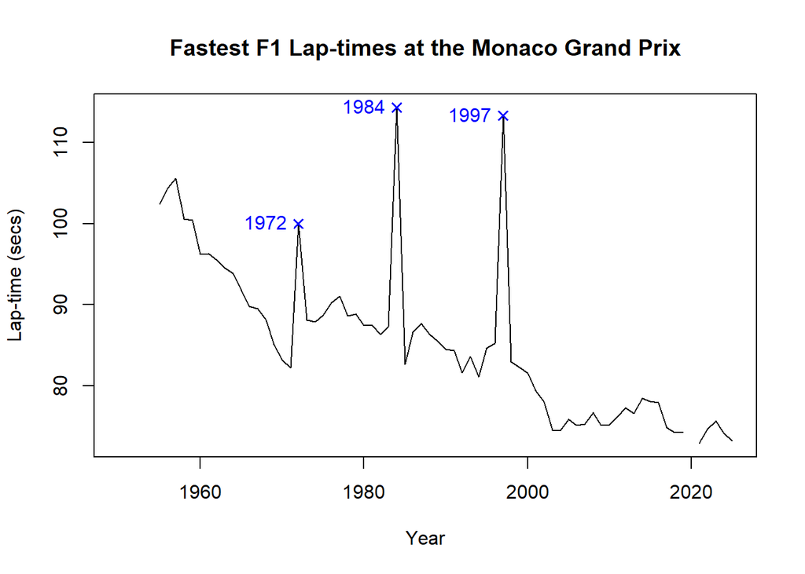

```r
#looking at the data frame the years where it spikes can be found
spike_years=c(1972,1984,1997)
spike_lap_times=montecarlo_time_series[match(spike_years,time(montecarlo_time_series))]
plot(montecarlo_time_series,
     main='Fastest F1 Lap-times at the Monaco Grand Prix',
     ylab='Lap-time (secs)', xlab='Year')
points(spike_years,spike_lap_times,col='blue',pch=4,cex=1,lwd=1.5)
text(spike_years,spike_lap_times,labels=spike_years,pos=2,col='blue')
```

*In this graph of the time series the spiked lap times are displayed with a blue cross and the year in which they occurred.*

At first you may look at these points and think that there is an error in the metrics because the represent increases in lap time by almost 30 seconds at times, which may not sound like a lot but in this sport a thousandth of a second can be the difference between victory and failure. However, there are no mistakes in this data and there are reasons for these outliers!

During these three years the Monaco Grand Prix was held entirely under wet conditions (heavy rain) with not a single race lap time set with the absence of rain. Rain causes the tyres to have drastically less grip on the track surface (especially such torrential rain which occurred in these three races), even requiring specialised “Wet” tyres to be fitted to the cars to give the drivers just a chance at keeping their car out of the walls.

The spike at 1972, though it is still much higher than surrounding years, is noticeably lower than the 1984 and 1997 times (by approximately 14 seconds). This is because in 1972 the race was able to be held in full, giving the drivers a chance to practice and adapt to the torrid conditions compared to the latter two races which were cut short due to safety concerns.

# Meta Prophet Forecasting:

Now that we have analysed in depth the known data points, let’s use the Prophet tools to produce a forecast of what Formula 1 lap times might look like in the future.

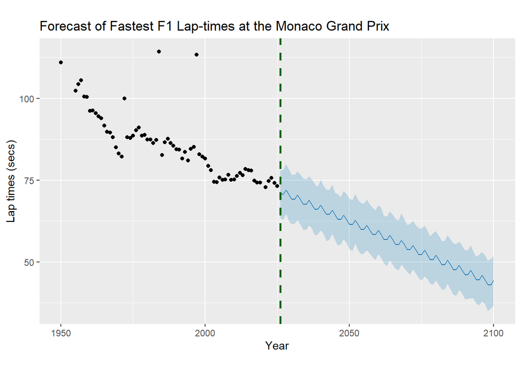

```r
#prophet forecasting steps
montecarlo_prophet_model=prophet(montecarlo_dataframe)
future_dataframe=make_future_dataframe(montecarlo_prophet_model,
                                       periods=75, freq='year',
                                       include_history = FALSE)
predictive_dataframe=predict(montecarlo_prophet_model,future_dataframe)
forecast=plot(montecarlo_prophet_model,predictive_dataframe,
              ylab='Lap times (secs)',xlab='Year')
forecast+geom_vline(xintercept=as.Date('2026-01-01'),colour='darkgreen',
                    linetype='dashed',linewidth=1)+
    ggtitle('Forecast of Fastest F1 Lap-times at the Monaco Grand Prix')
```

*This graph shows the known time series data, in black dots, the prophet model’s forecasted trend, the blue line, and a prediction interval of the forecasted trend, the shaded region around the blue line. There is also a green dashed line where the forecast begins. The graph forecasts data for the next 75 years until the year 2100.*

From this forecasted trend we can see that the prophet model predicts the lap times to follow an overall downward trend from 2026 to 2100, eventually dropping below 50 seconds in the later years of the period. This portrays the same decreasing trend that we saw from the linear regression model of the time series earlier. However, the prophet model also takes into account the random noise element of the data where we see lap times can occasionally increase in following years due to extraneous factors. The model shows this in periodic peaks and troughs in the negatively sloped line, representing variability.

Statistically speaking, it is impossible for this trend line to be correct at any one point due to the continuous nature of the data, it is simply given to show an idea of where the future data points should lie near to. This is why prophet also calculates a prediction interval around this trend. The interval that prophet calculates is an 80% prediction interval, meaning that, with probability 0.8, the future data points should lie within this interval. The interval is a similar width across the predictive window and allows for more variability in the data. Focusing on the steady decline in lap time from around 1975 to present 2025 it seems clear that this interval is very accurate and should contain most future points (other than potentially any future races that are held completely under wet conditions again or any other anomalies).

# Evaluation:

There are a few important potential arguments against this data or analysis that should be considered.

## Issues with the Data

The time series of lap times that this project is based on can be viewed as relatively small, around 75 points, when it comes to methods like forecasting future data. This is due to the fact that there is only one lap time (the fastest) taken from each race which happens at most once a year. This leads to issues such as no seasonality, which has a major effect on the shape of the prophet forecast, giving it more of a noticeable downward direction rather than containing seasonal variation. If for example there were two races held per year at this track, one in June and one in December, there would undoubtedly be a seasonality component to this time series, that being that the December data would likely have higher lap times than the June data due to chances of rain and more simply better conditions for car performance.

Another problem with a small data set is that, when one new data point is observed and added to the previous ones, it can have a great deal of effect on things like the linear regression line and again the predicted future trend. This is due to there being a higher weighting on the new data point as there is less in total, that is if they are all equally contributing explanatory power.

## Extraneous Factors

There are a few factors that have already been mentioned - such as regulation changes and weather conditions - as possible explanations to how the data has acted in certain periods or specific points, but there are a couple others that have yet to be mentioned.

One potential disturbance to the lap times over the years is the matter of the track layout. The Monte-Carlo circuit is a street circuit that traverses the public streets (and harbour) of Monaco and because of this the track is set up and taken down again every year by closing roads to public and arranging the race on the existing layout of the city. This means that when changes happen to the layout of the city roads that are typically raced on in the Grand Prix, changes to the track layout may also have to occur. One of the most notable instances was in the mid 1970s where the city conducted some urban redevelopment, expanding land into the sea near the harbour and introducing a swimming pool complex. This lead to the track having to be rerouted around this section of the circuit and lead to an initial rise in lap times due to increased technicality before gradually dropping again. Many other changes were made to the track layout such as additions of corners in the middle of straights due to safety concerns. Although the Monte-Carlo circuit has more or less remained the same since its induction to F1, these variations could explain discrepancies in lap time.

Another candidate for discussion is that of the drivers. We have already discussed the idea of the regulations limiting the lap times, so if we were to ignore that and allow any possible use of automotive engineering in this race there would still be the issue of human limits. Throughout the years drivers of these cars have had to endure increasingly tough conditions (in terms of G-Force) in order to race here with drivers in recent years experiencing up to 4G laterally in corners and 5G longitudinally when braking. This track famously features constant cornering and has no real rest periods for the drivers’ bodies meaning that, in this current rule set, it is already extremely difficult to keep the precision driving needed to survive the full race. It is obviously possible to engineer a car that is able to set a much faster lap time than we have ever seen around this circuit theoretically of course, but overall it must be physically possible for the driver to survive a race (or even a lap) in such a machine. Due to this there will most likely eventually be a plateau in lap times in the future where laps are being driven as fast as humanly possible which is not portrayed in the forecast above.

# References

GP Racing Stats (2026) ‘Monaco Grand Prix fastest laps’. Available at: https://gpracingstats.com/circuits/monte-carlo/fastest-laps/ (Accessed: 19 March 2026).